# 12th March

Anna Hutchinson

## 1. cFDR

### Transform q values to normal distribution

A quick fix would be to convert the q values to a normal distribution and then directly use James’ functions.

The `bestNormalize` package (https://cran.r-project.org/web/packages/bestNormalize/vignettes/bestNormalize.html) allows comparison between different normalisation methods (where normalisation refers to making data normal, i.e. not just $[0,1]$).

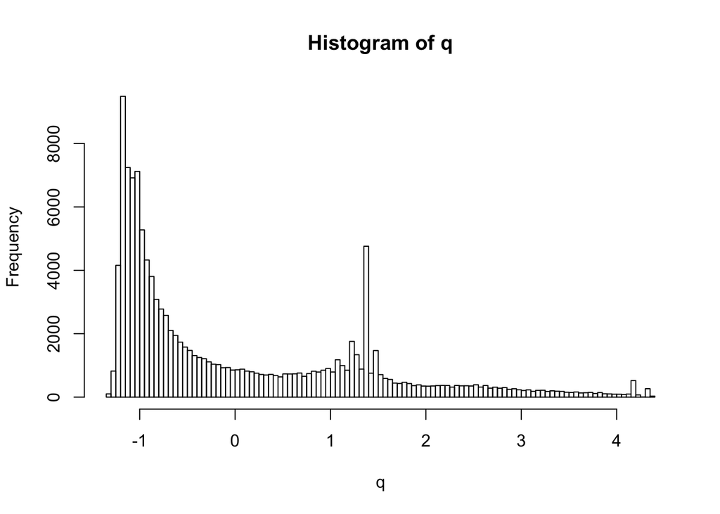

```r
mca_df <- readRDS("res.mca.mjca.RDS")
q <- mca_df[,1]
hist(q, breaks = 100)
```

I use the package to find the recommended method for normalisation. The package suggests the ordered quantile (ORQ) normalization via `orderNorm`, a normalization technique based off of a rank mapping to the normal distribution, which guarantees normally distributed transformed data (if ties are not present).

```r
library(bestNormalize)
(BNobject <- bestNormalize(q))
```

```
## Best Normalizing transformation with 121879 Observations
##  Estimated Normality Statistics (Pearson P / df, lower => more normal):
##  - No transform: 248.0488
##  - Log_b(x+a): 62.4443
##  - sqrt(x+a): 91.907
##  - exp(x): 2179.1578
##  - arcsinh(x): 291.9998
##  - Yeo-Johnson: 131.9365
##  - orderNorm: 4.6778
## Estimation method: Out-of-sample via CV with 10 folds and 5 repeats
##
## Based off these, bestNormalize chose:
## orderNorm Transformation with 121879 nonmissing obs and ties
##  - 102874 unique values
##  - Original quantiles:
##     0%    25%    50%    75%   100%
## -1.344 -1.038 -0.620  0.997  4.357
```

The annotation data is now normally distributed.

```r
orderNorm_obj <- orderNorm(q)
```

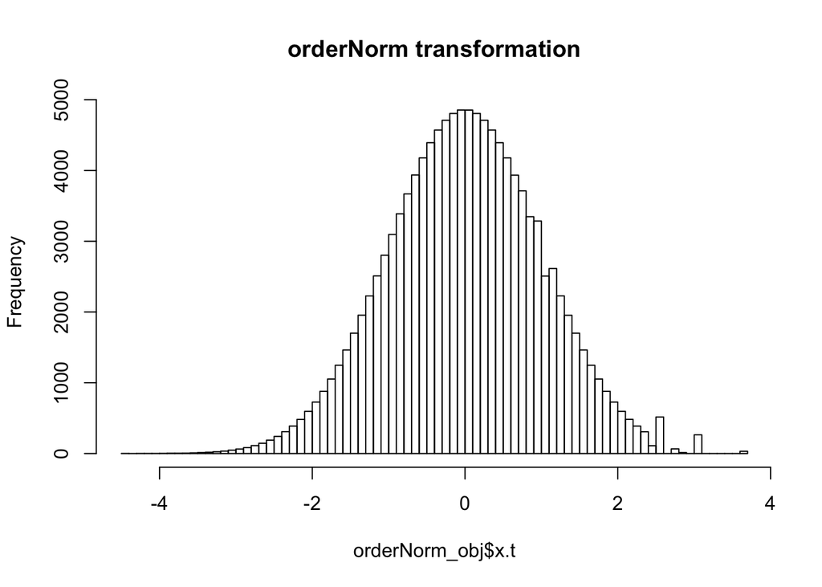

```r
hist(orderNorm_obj$x.t, main = "orderNorm transformation", breaks = 100)
```

### Problem

```r
final_dataset <- readRDS("final_dataset.RDS")

q <- readRDS("transformed_q.RDS")

p <- final_dataset$p

source("cfdr_functions.R")

# p[which(p<1e-300)] <- 1e-300 # to avoid errors in James' code
# q[which(qs<1e-300)] <- 1e-300

candidate_indices <- which(p < 1)

chr <- final_dataset$chrom

est_q0_pars <- fit.2g(q[which(p>0.5)])$pars

# prepare containers
fold <- vector(mode = "list", length = length(unique(chr)))
ind <- vector(mode = "list", length = length(unique(chr)))
L <- vector(mode = "list", length = length(unique(chr)))
v <- vector(mode = "list", length = length(unique(chr)))

for(i in 1:length(unique(chr))){
  fold[[i]] <- which(chr == i)
  ind[[i]] <- intersect(candidate_indices, fold[[i]])
  L[[i]] <- vl(p, q, indices=ind[[i]], mode=2, fold=fold[[i]], gx = min(p[ind[[i]]]));  # compute L curves

  v[[i]] <- il(L[[i]], pi0_null = est_q0_pars[1], sigma_null = est_q0_pars[2], distx="norm", gx = min(p[ind[[i]]])) # integrate over L curves
}

save(p, q, v, file = "transform_res.RData")
```

## 2. Figure for fine-mapping review

1. On the HPC (in `review_PAINTORfig`) generate many simulated locus files:
   1. Fix OR=1.1, NN=10000 and randomly select a CV to generate Z scores for the “medium” LD region (714 SNPs).
   2. Generate corresponding random annotation vector using `rbinom(length(z), 1, pi)` with `pi=0.1`.
   3. Save locus file (consisting of Z scores), ld file (note that this will be the same for all simulations) and annotations file to be used as input into PAINTOR.
   4. Store the iCV and binary annotaion at the CV (in `review_PAINTORfig/res/misc/`)
   5. REPEAT (i)-(iv) many times (600 times).
2. Select subsets of datasets to be used as input into PAINTOR (see `make_inputfiles.R`):
   1. Select 10 collections of 100 locus files whereby the proportion of CVs with annotation equal to 1 is `pi` (annotation uninformative). Make `input.files` and run PAINTOR for each of these 10. Save the PP at the CV in each (so have 10*100 PPs).
   2. Select 10 collections of 100 locus files whereby the proportion of CVs with annotation equal to 1 is `0.2` (annotation informative - CVs more likely to have it). Make `input.files` and run PAINTOR for each of these 10. Save the PP at the CV in each (so have 10*100 PPs).
   3. Select 10 collections of 100 locus files whereby the proportion of CVs with annotation equal to 1 is `0.05` (annotation informative - CVs less likely to have it). Make `input.files` and run PAINTOR for each of these 10. Save the PP at the CV in each (so have 10*100 PPs).
3. Compare PPs for CVs.

### Results

```r
res_pi <- readRDS("/Users/anna/PAINTOR_V3.0/misc/res_pi.RDS")

res_lower <- readRDS("/Users/anna/PAINTOR_V3.0/misc/res_lower.RDS")

res_higher <- readRDS("/Users/anna/PAINTOR_V3.0/misc/res_higher.RDS")

# remove problematic simulations where all SNPs are given PP=1 for some reason

res_pi <- res_pi[-which(res_pi$PPs==1 & res_pi$ranks!=1),]
res_lower <- res_lower[-which(res_lower$PPs==1 & res_lower$ranks!=1),]
res_higher <- res_higher[-which(res_higher$PPs==1 & res_higher$ranks!=1),]
```

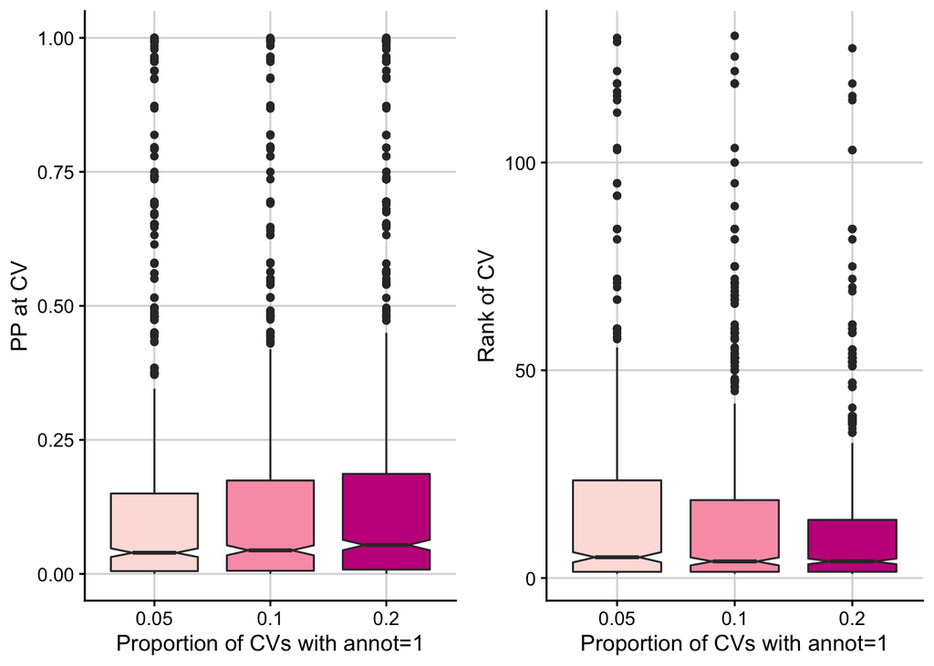